# visiumSpatialSolutions: Fiducial Detection

# Introduction

`visiumSpatialSolutions` provides tools for spatial reconstruction, visualization, and interactive analysis of non-HD Visium spot-based arrays, including:

- visual assessment of fiducial detection and coordinate orientation,
- conversion between array and pixel spot positions into spatial dimensions,
- spatially resolved visualization,
- interactive spot selection within the spatially resolved image,
- visualization and interactive adjustments of selected spot positions, and
- download of interactively selected spots.

# Installation

You can install the development version of visiumSpatialSolutions from [GitHub](https://github.com/Zockimonster/visiumSpatialSolutions) with:

```r
# install.packages("devtools")
# devtools::install_github("Zockimonster/visiumSpatialSolutions")
# or
# install.packages("remotes")
remotes::install_github("Zockimonster/visiumSpatialSolutions")
```

Afterwards, the package can be loaded, using

```r
library(visiumSpatialSolutions)
```

# Vignette Datasets

Throughout the vignettes we will use the following datasets:

- [Visium_FFPE_Human_Ovarian_Cancer](https://www.10xgenomics.com/datasets/human-ovarian-cancer-1-standard)
- [CytAssist_11mm_FFPE_Human_Ovarian_Carcinoma](https://www.10xgenomics.com/datasets/human-ovarian-cancer-11-mm-capture-area-ffpe-2-standard)

The required files can be downloaded and extracted using the function `download_vignette_files()`.

Alternatively, you can use your own data.

## Download Vignette Data

First, we need to define an output directory (`output_dir`), where the downloaded sample folders (`small_sample` and / or `large_sample`) should be created:

```r
# define output directory
output_dir <- file.path(getwd(), "data")
# define sample names
small_sample <- "Visium_FFPE_Human_Ovarian_Cancer"
large_sample <- "CytAssist_11mm_FFPE_Human_Ovarian_Carcinoma"
```

The download helper is intended to enable running the package-related vignettes, only. For downloading the full dataset or a distinct set of files, all files are available for download in `Output and supplemental Files` on the Visium website.

All downloaded files and folders will be saved to `<output_dir>/<visium_dir>/<visium_sample>/outs/`, to match the expected Space Ranger output structure.

Downloaded files include:

- Matrix Files: Filtered (default) and/or raw matrix (`matrix_name`) in h5 (default) or sparse file format (`matrix_file_format`). If the sparse file format is selected, a folder `<matrix_name>_feature_bc_matrix` with the `matrix.mtx`,`features.tsv` and `barcodes.tsv` files will be created in `<output_dir>/<visium_dir>/<visium_sample>/outs/`. Since this file format requires approx. 2.5-times as much memory, h5 is selected as default file format.
- Spatial Files: The low (default) and / or high resolution tissue image (`image_resolution`), the detected_tissue_image, the scalefactors_json.json file (Distinct from 10X Loupe Browser Manual Alignment json file!),and the tissue position csv file. All spatial files will be saved to a `spatial` folder created in `<output_dir>/<visium_dir>/<visium_sample>/outs/`.

```r
# Download vignette-related files for the
# Human Ovarian Cancer 6.5mm dataset and for the
# Human Ovarian Cancer 11mm dataset
download_vignette_files(output_dir = output_dir, visium_sample = c(small_sample, large_sample),
                        matrix_file_format="h5", matrix_name = "filtered", image_resolution=c("lowres", "hires"))
# based on default settings identical to
# download_vignette_files(output_dir = output_dir, image_resolution=c("lowres", "hires"))
```

## Check Fiducial Alignment

```r
plot_title_small_sample <- "Human Ovarian Cancer (Visium FFPE, 6.5mm Array)"
plot_title_large_sample <- "Human Ovarian Cancer (Visium FFPE, CytAssist, 11mm Array)"

# define figures directory
figures_dir <- file.path(getwd(), "figures")
# figures for Visium_FFPE_Human_Ovarian_Cancer (small sample)
figures_6500 <- file.path(figures_dir, small_sample)
dir.create(figures_6500, recursive = TRUE, showWarnings = FALSE)
# figures for CytAssist_11mm_FFPE_Human_Ovarian_Carcinoma (large sample)
figures_11000 <- file.path(figures_dir, large_sample)
dir.create(figures_11000, recursive = TRUE, showWarnings = FALSE)
```

For correct Fiducial Detection, the hollow circles must match the grey dots in the four corners (Fiducial Markers) in the `detected_tissue_image` resp. in the `aligned_fiducials` image, as well as for the lines in between (Fiducial Frame). This ensures proper alignment of matrix barcode positions, encoding the gene counts per spot, and the barcodes in the tissue position file.

To check the correct fiducial alignment and for aligning the array and pixel positions with the tissue image, you can use the function `check_fiducial_alignment()`.

The function expects the standard Space Ranger directory structure `<visium_dir>/<visium_sample>/outs/spatial/` with the visium directory (`visium_dir`) and sample folder (`visium_sample`).

From the `spatial` sub directory the tissue image (`tissue_<image_resolution>_image`), the`detected_tissue_image` and the tissue positions file (`tp_file_name`) will be loaded, and a named list will be returned:

- tissue_image: A `ggplot` object with the tissue image in the selected resolution (NULL, if the image couldn’t be loaded).
- detected_tissue_image: A `ggplot` object showing the detected tissue with the aligned fiducial frame (NULL, if the image couldn’t be loaded).
- array_spots: A `ggplot` object showing the Visium array-grid positions.
- pixel_positions: A `ggplot` object showing the spot-related pixel coordinates in the full-resolution image.}
- tp: The tissue positions `data.frame` with named attribute `orientation_adjustments`, including information about adjustments made to the array positions `adjust_array` and to the pixel positions `adjust_pixels`.

### Small Array

```r
check_alignment <- check_fiducial_alignment(visium_dir=output_dir, visium_sample= small_sample,
                                            tp_file_name="tissue_positions_list.csv")
```

**Note: In older Space Ranger Version (before 2.0.0), the tissue positions file had no header, and the file name was `tissue_positions_list.csv`.**

```r
combined_plot <- ggpubr::ggarrange(check_alignment[["tissue_image"]],check_alignment[["detected_tissue_image"]],
                                   check_alignment[["array_spots"]], check_alignment[["pixel_positions"]],
                                   ncol=2, nrow=2, common.legend = TRUE, legend="bottom")
# optionally, save the unmodified combined plot grid
ggplot2::ggsave(filename = file.path(figures_6500, "check_alignment.jpg"), plot= combined_plot, width = 10, height = 10, units = "in")
```

Alternative packages for combining ggplot objects include:

- `gridExtra::grid.arrange()`,
- `patchwork::wrap_plots()`,
- `cowplot::align_plots()`

[figure not shown]

### Large Array

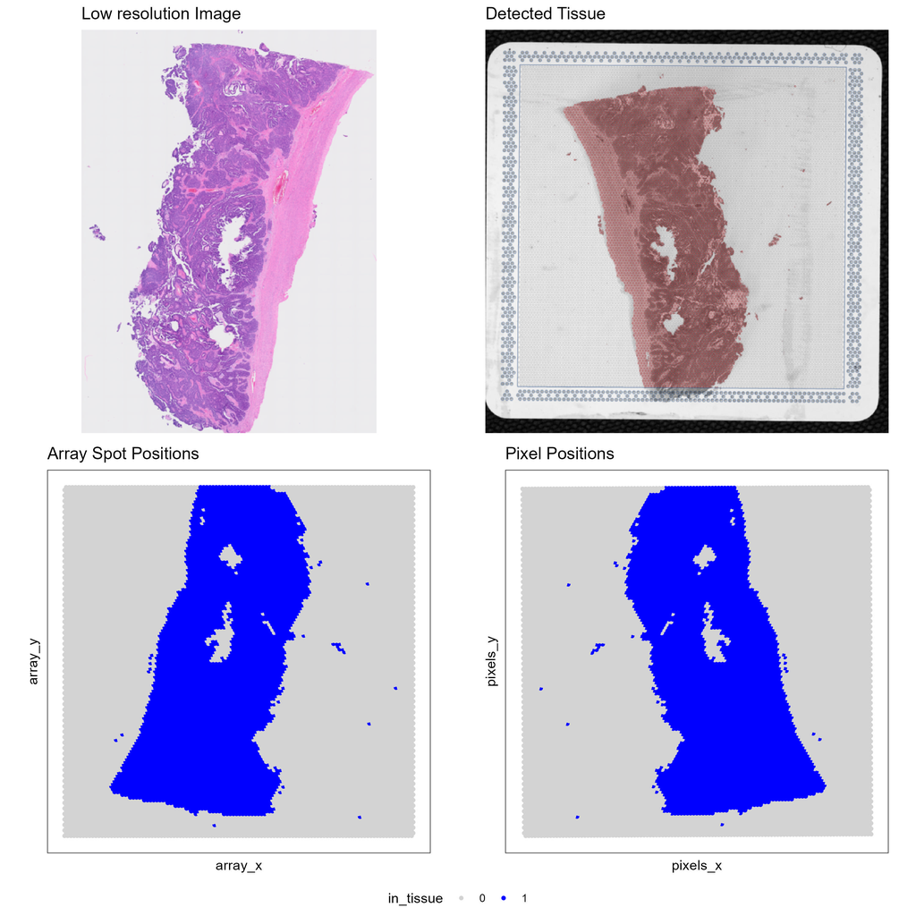

```r
check_alignment <- check_fiducial_alignment(visium_dir=output_dir, visium_sample= large_sample)
# combine
combined_plot <- ggpubr::ggarrange(check_alignment[["tissue_image"]],check_alignment[["detected_tissue_image"]],
                                   check_alignment[["array_spots"]], check_alignment[["pixel_positions"]],
                                   ncol=2, nrow=2, common.legend = TRUE, legend="bottom")
# optionally, save the unmodified combined plot grid
ggplot2::ggsave(filename = file.path(figures_11000, "check_alignment.jpg"), plot= combined_plot, width = 10, height = 10, units = "in")
```

## Image Positions and Coordinates

To adjust the coordinates within the `tissue_positions` file to match the tissue image (`lowres` or `hires`), you can adjust the orientation the array positions using the `adjust_array` resp. of the pixel positions using the `adjust_pixels` argument in the function.

The `adjust_array` resp. `adjust_pixels` arguments enable 3 reorientation steps in the following order:

1. `swap`: changes the row and column axis
2. `x` mirrors the column positions (min <-> max)
3. `y` mirrors the row positions (min <-> max)

**Note: These arguments do only change the visualization of array (`adjust_array`) resp. pixel positions (`adjust_pixels`) for visual alignment of the tissue image and the spot positions. They do not change the barcodes assigned to each spot, and therefore aren’t sufficient for realigning Space Ranger output in case of misaligned Fiducial Markers.**

### Swapping requirements

Without swapping correction the axes positions, including the number of spots assigned to the axes positions will match the coordinate axes:

10x array Cartesian coordinate

*col* position ───────────────► *x* axis *row* position ───────────────► *y* axis

If Swapping correction is required to match the array (`adjust_array`) or pixel (`adjust_pixels`) axis positions to match the tissue image, the ranges and number of spots assigned to the axes positions will also be changed at the coordinate axes:

10x array Cartesian coordinate

*col* position ───────────────► *y* axis *row* position ───────────────► *x* axis

Though the hollow circles match the grey dots, indicating the correct detection of the Fiducial Markers and of the Fiducial Frame, the orientation of the array and the pixel positions doesn’t match the image orientation.

### Small Array

Though correct fiducial alignment, the array and pixel positions don’t match the orientation of the tissue image.

Too align the array and pixel positions with the tissue image for the `Visium_FFPE_Human_Ovarian_Cancer` sample, we can mirror the y axis for array (`adjust_array = "y"`) and pixel positions (`adjust_pixels = "y"`):

```r
check_alignment <- check_fiducial_alignment(visium_dir=output_dir, visium_sample= small_sample,
                                            tp_file_name="tissue_positions_list.csv", adjust_array = "y",
                                            adjust_pixels = "y")
```

Next, we save the aligned tissue position as `rds` and `csv` files:

```r
save_aligned_tp(tp = check_alignment$tp, out_dir = output_dir, visium_sample = small_sample, file_type = c("rds", "csv"))
```

For combining and saving the resulting plot grid, we use:

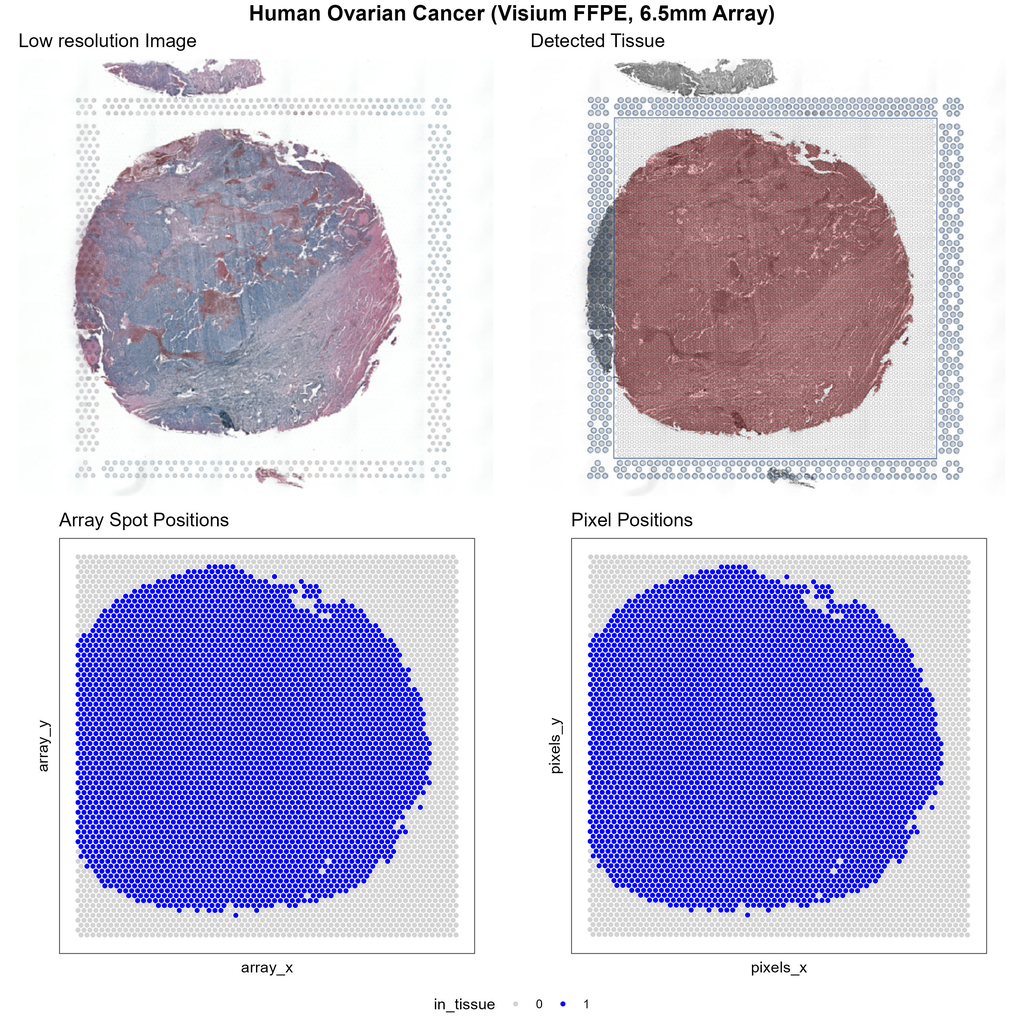

```r
combined_plot_adj <- ggpubr::ggarrange(check_alignment[["tissue_image"]],check_alignment[["detected_tissue_image"]],
                                   check_alignment[["array_spots"]], check_alignment[["pixel_positions"]],
                                   ncol=2, nrow=2, common.legend = TRUE, legend="bottom")
combined_plot_adj <- ggpubr::annotate_figure(combined_plot_adj,
                                             top = ggpubr::text_grob(plot_title_small_sample,
                                                                     color = "black", face = "bold", size = 15))
# save aligned combined plot grid
ggplot2::ggsave(filename = file.path(figures_6500, "check_alignment_adjusted.jpg"), plot= combined_plot_adj, width = 10, height = 10, units = "in")
```

### Large Array

This time also the array and pixel positions don’t align, implying distinct reorientation requirements.

To match the positions of the array with the tissue image, we can mirror the array positions at the x- and the y-axis. The pixel positions need the be mirrored at the y-axis, only. Saving the aligned tissue positions and the combined plot grid works like before:

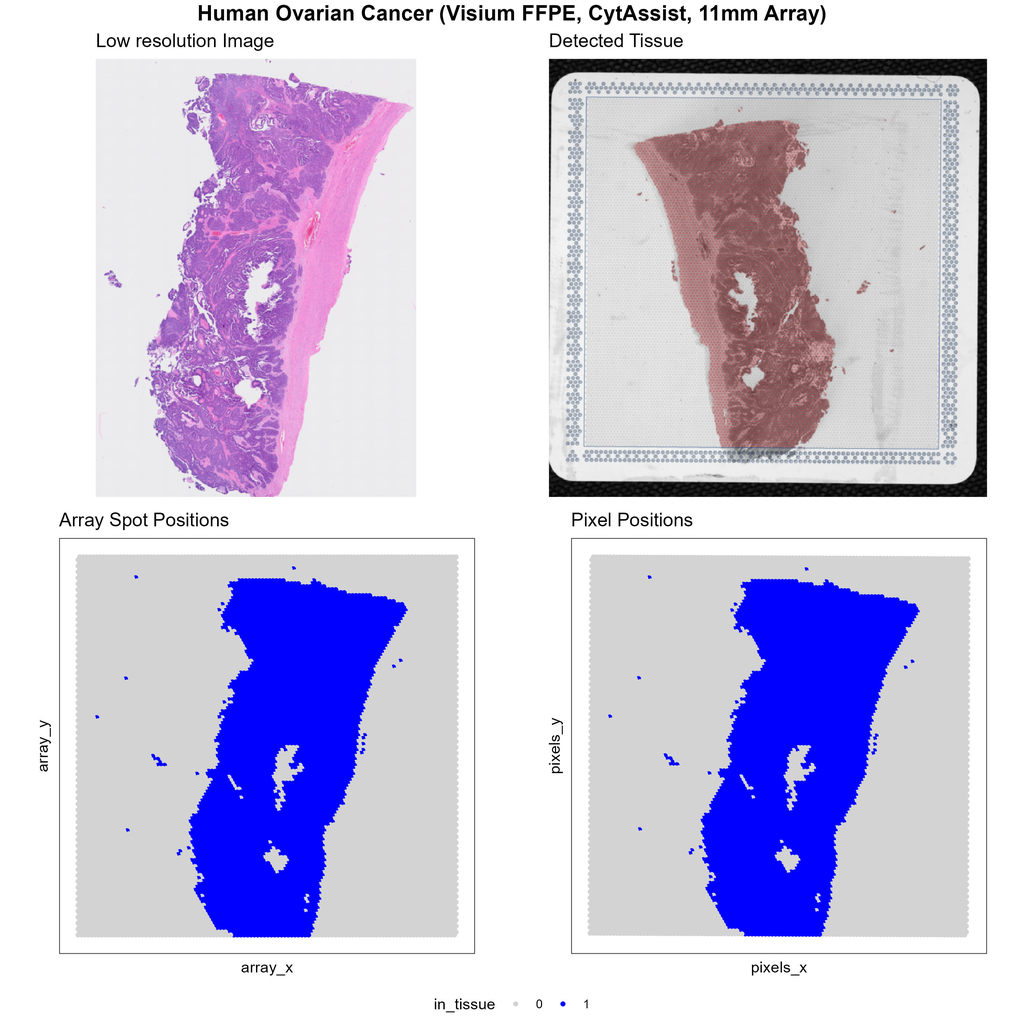

```r
check_alignment <- check_fiducial_alignment(visium_dir=output_dir, visium_sample= large_sample,
                                            adjust_array = c("x", "y"), adjust_pixels = "y")
# save aligned tissue position information
save_aligned_tp(tp = check_alignment$tp, out_dir = output_dir, visium_sample = large_sample, file_type = c("rds", "csv"))
# combine & add a common title
combined_plot_adj <- ggpubr::ggarrange(check_alignment[["tissue_image"]],check_alignment[["detected_tissue_image"]],
                                   check_alignment[["array_spots"]], check_alignment[["pixel_positions"]],
                                   ncol=2, nrow=2, common.legend = TRUE, legend="bottom")
combined_plot_adj <- ggpubr::annotate_figure(combined_plot_adj,
                                             top = ggpubr::text_grob(plot_title_large_sample,
                                                                     color = "black", face = "bold", size = 15))
# save aligned combined plot grid
ggplot2::ggsave(filename = file.path(figures_11000, "check_alignment_adjusted.jpg"), plot= combined_plot_adj, width = 10, height = 10, units = "in")
```

## Misalignment

In contrast to simple orientation issues of array and pixel positions, a misalignment of Fiducial Markers and the Fiducial Frame would result in mismatches of barcoded spots in the gene count matrix files and the tissue position file. This can’t be resolved by changing the orientation of the array or the pixels. In this situation [Manual Realignment](https://www.10xgenomics.com/support/software/space-ranger/latest/analysis/inputs/image-fiducial-alignment), would be required, before proceeding.

For demonstration purposes, we imitated the misalignment of the fiducial markers, using the Visium 6.5mm slide:

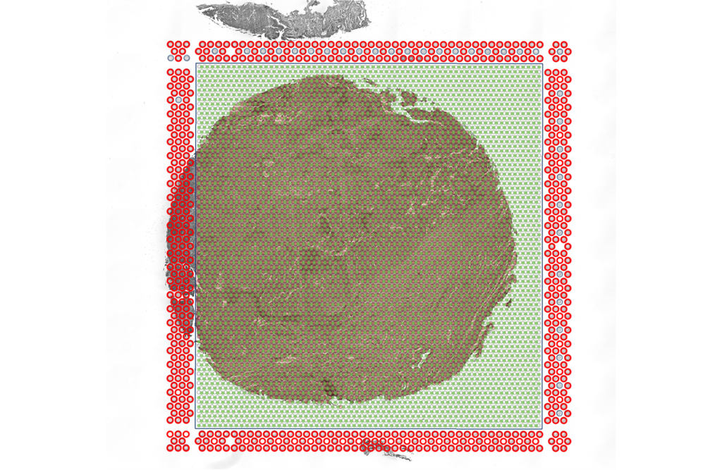

**Examplary Misalignment for the 6.5mm Visium capture area.**

To streamline the process of [Manual Realignment](https://www.10xgenomics.com/support/software/space-ranger/latest/analysis/inputs/image-fiducial-alignment), we started creating visiumReorientation, which helps with re-running Space Ranger, if the automatic alignment failed. Further reorientation approaches are still under evaluation, and will be available within this package in the future.

> **Marker Positions**